# gperez_Assig_7

Gera

9/10/2019

This is an exercise in bash and R to do RNA-Seq differential expression analysis.

setwd(“/Users/gerardoperez/Documents/shell/Bi623/Assign7”)

All files for this assignment may be found in: /projects/bgmp/shared/Bi623/assign7/

1. HTSeq-count

Copy or link these files to a working directory on Talapas:

```bash
cd bgmp/projects/bgmp/gperez8/Bi623/Ex7

scp /projects/bgmp/shared/Bi623/assign7/Bt* .
```

Write an sbatch script (submitted as a job on Talapas) to count the number of reads mapping uniquely to each gene in the stickleback reference, for all SAM files.

```bash
#!/bin/bash

#SBATCH --account=bgmp
#SBATCH --partition=bgmp
#SBATCH --job-name=htseq
#SBATCH --output=slurm-%j-%x.out

#SBATCH --time=0-01:00:00
#SBATCH --nodes=1
#SBATCH --ntasks-per-node=1
#SBATCH --cpus-per-task=8


conda deactivate
conda deactivate
conda deactivate
conda deactivate
conda activate bgmp_py3

ml purge ml slurm easybuild intel/2017a HTSeq/0.9.1-Python-3.6.1

/usr/bin/time -v python -m HTSeq.scripts.count --mode union --type exon --stranded no   Bt_conv_5.unpaired_uniq   Bt_conv_6.unpaired_uniq   Bt_conv_7.unpaired_uniq   Bt_mono_2.unpaired_uniq   Bt_mono_6.unpaired_uniq   Bt_mono_7.unpaired_uniq  Gasterosteus_aculeatus.BROADS1.85.gtf>Gacu_readcounts.txt
```

Note the column totals calculated by htseq-count, at the bottom of your file. (Naturally, you would normally exclude these in R before any kind of differential expression analysis.) What information do these totals contain?

```bash
tail  Gacu_readcounts.txt
ENSGACG00000022902  0   0   0   0   0   0
ENSGACG00000022903  0   0   0   0   0   0
ENSGACG00000022904  0   0   0   0   0   0
ENSGACG00000022905  0   0   0   0   0   0
ENSGACG00000022906  0   0   0   0   0   0
__no_feature    135045  124896  139486  109555  136855  83517
__ambiguous 2566    2712    2605    2595    2681    2264
__too_low_aQual 0   0   0   0   0   0
__not_aligned   0   0   0   0   0   0
__alignment_not_unique  0   0   0   0   0   0
```

**The information that contains are columns of number reads that have no features, were ambiguous, discarded due to low quality sequencing , unaligned reads, and reads with non unique alignments. This inform us of what was discarded.**

2. Evaluating the effect of normalization on count data

In R, read in the file /projects/bgmp/shared/Bi623/assign7/Gacu_gut_counts.tsv (name the df “Counts”)

Copy file to a working directory on Talapas:

```bash
scp hpc:/projects/bgmp/shared/Bi623/assign7/Gacu_gut_counts.tsv .
```

```r
# sets the directory to save files from this Rscript
setwd("/Users/gerardoperez/Documents/shell/Bi623/Assign7")
knitr::opts_knit$set(root.dir = "/Users/gerardoperez/Documents/Bio623/Ex6" )

library(edgeR)
library(VennDiagram)
```

In R, read in the file /projects/bgmp/shared/Bi623/assign7/Gacu_gut_counts.tsv (name the df “Counts”) When you read in the file, set row.names=1, and stringsAsFactors=FALSE.

```r
setwd("/Users/gerardoperez/Documents/shell/Bi623/Assign7")

# import file into R for analysis
Counts<- read.table("Gacu_gut_counts.tsv",  header=T,  row.names=1, stringsAsFactors=FALSE, sep="\t")
```

Using the unnormalized values in Counts, plot library 1A_02 values vs. library 1A_03 values. Draw a line through the origin (intercept=0) with slope=1, which would be the expectation for equal counts between the two libraries.

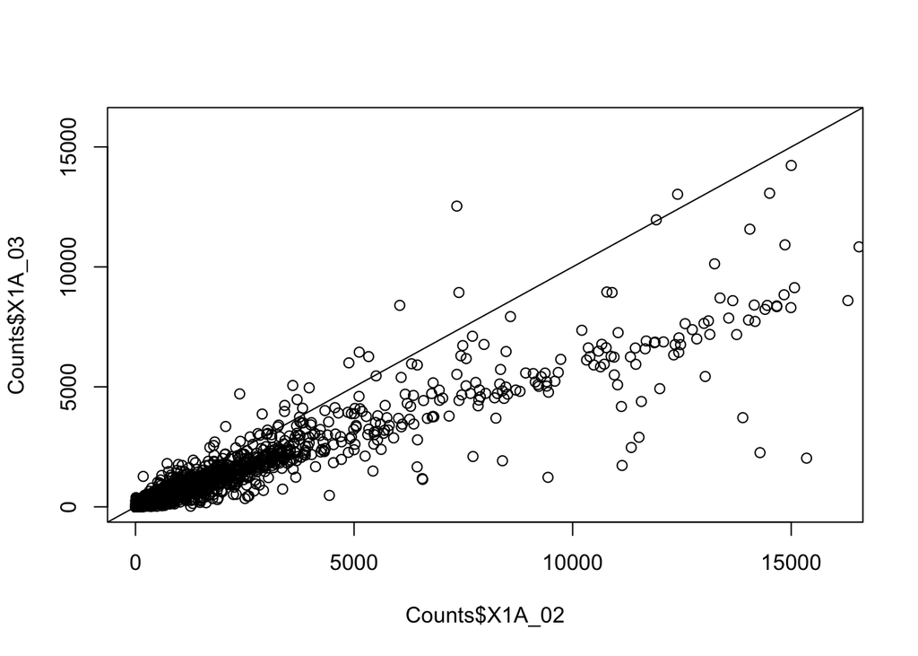

```r
# Creates a plolt with certain parameters.
plot(Counts$X1A_02, Counts$X1A_03, xlim=c(0,16000), ylim=c(0,16000))
# Creates a line that has Y intercept at 0 and a slope of 1
abline(a=0, b=1)
```

What do you notice about the relationship between counts for these libraries?

**The relationship between both counts is that majority is not a one to one relationship. Meaning that the genes are not evenly expressed.**

Now plot the normalized expression values for library 1A_02 vs those for library 1A_03 as above, including the slope=1 line

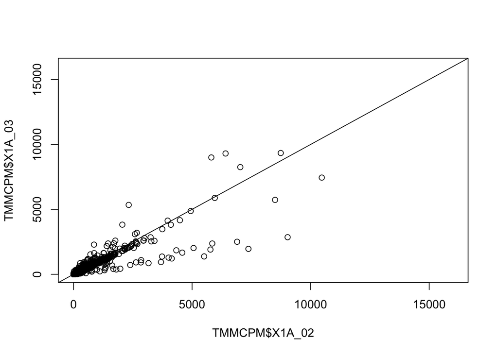

```r
# stores the raw counts as a “DGEList” object.
dge <- DGEList(counts=Counts)

# Calculates TMM normalization factors and adds it to dge
dge <- calcNormFactors(dge)

# Applies the TMM normalization factors and adjusts for library size by converting to copies per million (cpm)
TMMCPM <- as.data.frame(cpm(dge,
                        normalized.lib.sizes=TRUE))

# Creates a plolt with certain parameters.
plot(TMMCPM$X1A_02,TMMCPM$X1A_03, xlim=c(0,16000), ylim=c(0,16000))

# Creates a line that has Y intercept at 0 and a slope of 1
abline(a=0, b=1)
```

How has the relationship changed, and what does it mean regarding the effectiveness of normalization?

**The relationship between both counts has changed that they are now mojority one to one relationship. Meaning that the genes are evenly expressed and the normalization was effective.**

3. Testing and visualizing effects of Population and Treatment on differential expression using the negative binomial generalized linear model approach in edgeR (20 points total)

*My values were a little different compared to every one else. Could be the EdgeR version. Clay said this was ok.*

```r
#Define a new DGEList object to work with
dge.er <- DGEList(counts=Counts)

# Gets rid of genes expressed at low levels in many of the samples, which are not reliably tested. We only keep genes with at least one read per million (cpm) in at least 8 samples.
keep.dge.er <- rowSums(cpm(dge.er)>=1) >= 8
dge.er <- dge.er[keep.dge.er,]
dim(dge.er)
```

```
## [1] 16877    32
```

How many genes are we dealing with now?

**We are now dealing with 16877 genes.**

```r
# calculates TMM normalization factors
dge.er <- calcNormFactors(dge.er)

setwd("/Users/gerardoperez/Documents/shell/Bi623/Assign7")

# import file into R for analysis
Targets.er<-read.delim("Gacu_gut_metadata.tsv")


# Combines Population and Treatment variables into one
PopTrt <- paste(Targets.er$Population,
                Targets.er$Treatment, sep=".")

PopTrt
```

```
##  [1] "Bt.CV" "Bt.CV" "Bt.CV" "Bt.CV" "Bt.GF" "Bt.GF" "Bt.GF" "Bt.GF"
##  [9] "Bt.CV" "Bt.CV" "Bt.CV" "Bt.CV" "Bt.GF" "Bt.GF" "Bt.GF" "Bt.GF"
## [17] "RS.CV" "RS.CV" "RS.CV" "RS.CV" "RS.CV" "RS.CV" "RS.GF" "RS.GF"
## [25] "RS.GF" "RS.GF" "RS.GF" "RS.GF" "RS.CV" "RS.CV" "RS.GF" "RS.GF"
```

```r
# Uses the model.matrix() function to specify the experimental design
#generalized linear model that includes the “intercept” (0) and the effects of the 4 factor level combinations
design.er <- model.matrix(~0 + PopTrt)

design.er
```

```
##    PopTrtBt.CV PopTrtBt.GF PopTrtRS.CV PopTrtRS.GF
## 1            1           0           0           0
## 2            1           0           0           0
## 3            1           0           0           0
## 4            1           0           0           0
## 5            0           1           0           0
## 6            0           1           0           0
## 7            0           1           0           0
## 8            0           1           0           0
## 9            1           0           0           0
## 10           1           0           0           0
## 11           1           0           0           0
## 12           1           0           0           0
## 13           0           1           0           0
## 14           0           1           0           0
```

[output cut: 23 more lines]

```r
# 4 groups: Bt.CV, Bt.GF, RS.CV, and RS.GF
colnames(design.er)
```

```
## [1] "PopTrtBt.CV" "PopTrtBt.GF" "PopTrtRS.CV" "PopTrtRS.GF"
```

```r
#Estimates the dispersion parameter for each gene
dge.er <- estimateGLMCommonDisp(dge.er, design.er)
dge.er <- estimateGLMTrendedDisp(dge.er, design.er)
dge.er <- estimateGLMTagwiseDisp(dge.er, design.er)

#fits the full generalized linear model, incorporating the dispersion estimates
fit.er <- glmFit(dge.er, design.er)

# Contrast the average of Bt.CV and Bt.GF vs. the average of RS.CV and RS.GF, to test for the Population effect.
lrtPop <- glmLRT(fit.er, contrast=c(-.5,-.5,.5,.5))

#Looks at the genes with the lowest FDR-corrected p-values
topTags(lrtPop)
```

```
## Coefficient:  -0.5*PopTrtBt.CV -0.5*PopTrtBt.GF 0.5*PopTrtRS.CV 0.5*PopTrtRS.GF
##                        logFC   logCPM        LR        PValue
## ENSGACG00000020944  7.371826 5.839152 1041.4063 1.795562e-228
## ENSGACG00000016064 -4.031369 4.764007  580.7135 2.623432e-128
## ENSGACG00000009551 -2.955664 6.234024  448.0302  1.935564e-99
## ENSGACG00000019588  2.873130 5.298303  383.9256  1.739042e-85
## ENSGACG00000018602  2.484802 4.145942  319.0291  2.357150e-71
## ENSGACG00000020259  2.532350 4.946969  254.0132  3.463767e-57
## ENSGACG00000007674 -2.823229 5.452999  244.9624  3.256331e-55
## ENSGACG00000017175 -3.552164 3.874009  241.7396  1.642126e-54
## ENSGACG00000003825 -2.708820 5.147458  235.8816  3.109752e-53
## ENSGACG00000013202 -4.710729 4.409334  214.4211  1.490562e-48
##                              FDR
## ENSGACG00000020944 3.030369e-224
## ENSGACG00000016064 2.213783e-124
## ENSGACG00000009551  1.088884e-95
## ENSGACG00000019588  7.337454e-82
## ENSGACG00000018602  7.956325e-68
## ENSGACG00000020259  9.742998e-54
## ENSGACG00000007674  7.851013e-52
## ENSGACG00000017175  3.464269e-51
## ENSGACG00000003825  5.831476e-50
## ENSGACG00000013202  2.515621e-45
```

```r
#writes all of the test results to file
write.table(topTags(lrtPop, n=16877), 'edgeR_PopLRT.txt',
            sep='\t')

#Summarizes how many genes are differentially expressed by Population
de.er <- decideTestsDGE(lrtPop, p=0.05)
summary(de.er)
```

```
##        -0.5*PopTrtBt.CV -0.5*PopTrtBt.GF 0.5*PopTrtRS.CV 0.5*PopTrtRS.GF
## Down                                                                1320
## NotSig                                                             14125
## Up                                                                  1432
```

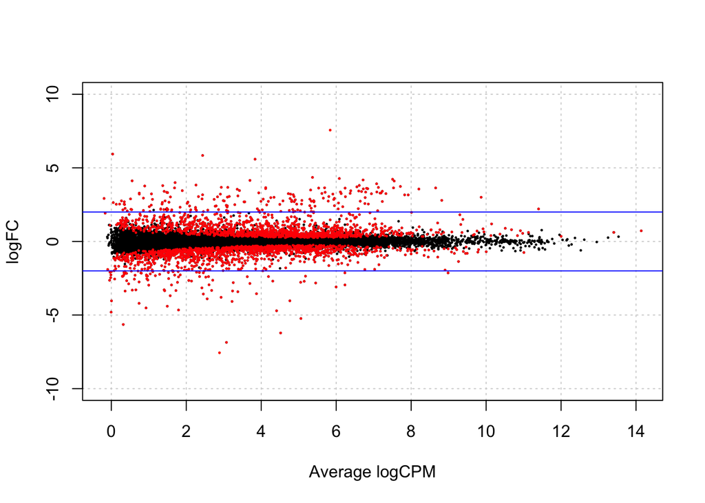

```r
#Visualizes the differential expression patterns with a “smear plot”
detags.er <- rownames(fit.er)[as.logical(de.er)]
plotSmear(lrtPop, de.tags=detags.er, ylim=c(-10,10))
abline(h = c(-2, 2), col = "blue")
```

What do the red dots represent, and what boundaries do the blue lines mark?

```r
# Contrast the average of Bt.CV and RS.CV vs. the average of Bt.GF and RS.GF for test for the Treatment (microbiota)
lrtTrt <- glmLRT(fit.er, contrast=c(-.5,.5,-.5,.5))

# Looks at the genes with the lowest FDR-corrected p-values
topTags(lrtTrt)
```

```
## Coefficient:  -0.5*PopTrtBt.CV 0.5*PopTrtBt.GF -0.5*PopTrtRS.CV 0.5*PopTrtRS.GF
##                        logFC    logCPM       LR       PValue          FDR
## ENSGACG00000017166 -2.676951 6.5470971 43.48028 4.282528e-11 7.227623e-07
## ENSGACG00000014415 -1.146976 4.6298272 28.06458 1.173336e-07 9.901196e-04
## ENSGACG00000012927 -1.239857 5.1617038 26.16114 3.140799e-07 1.766909e-03
## ENSGACG00000011948 -2.755730 3.7208663 24.37872 7.913795e-07 3.016250e-03
## ENSGACG00000006658 -1.766240 0.4235725 24.14474 8.935977e-07 3.016250e-03
## ENSGACG00000013747 -1.266271 4.4723562 23.75665 1.093170e-06 3.074906e-03
## ENSGACG00000008349  2.731992 6.7633382 22.00049 2.725813e-06 6.250224e-03
## ENSGACG00000010918 -3.547505 2.0935272 21.72390 3.148447e-06 6.250224e-03
## ENSGACG00000021894 -2.585360 4.1391875 21.61460 3.333058e-06 6.250224e-03
## ENSGACG00000015537 -1.077423 3.8982091 20.89958 4.840001e-06 8.136548e-03
```

```r
# Writes all of the test results to file
write.table(topTags(lrtTrt, n=16877), 'edgeR_TrtLRT.txt',
            sep='\t')

#Multiple Testing Across Genes And Contrasts. Giving the desired size of the test, 0.05.
de.er2 <- decideTestsDGE(lrtTrt, p=0.05)


dim(topTags(lrtTrt, n=16877,p.value = 0.05))
```

```
## [1] 49  5
```

How many genes are differentially expressed by Treatment?

**They are 49 genes that are differentially expressed by Treatment.**

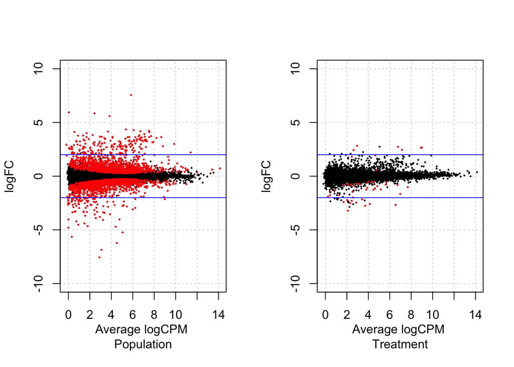

```r
# create smear plots for Population to Treatment comparison.
par(mfrow=c(1,2))
detags.er <- rownames(fit.er)[as.logical(de.er)]
plotSmear(lrtPop, de.tags=detags.er, ylim=c(-10,10), xlab="Average logCPM \nPopulation")
abline(h = c(-2, 2), col = "blue")

detags.er2 <- rownames(fit.er)[as.logical(de.er2)]
plotSmear(lrtTrt, de.tags=detags.er2, ylim=c(-10,10), xlab="Average logCPM \nTreatment")
abline(h = c(-2, 2), col = "blue")
```

How is it different from the Population smear plot?

**The difference is there is less differentially and signficantly expressed genes in the treatment compared to population.**

What does this say about the relative effects of stickleback population and microbiota treatment on gut gene expression in this experiment?

4. Testing effects of Population and Treatment on differential expression using the general linear model approach in limma (with voom())

```r
#Repeat everything you did for the edgeR analysis up to the dispersion estimates, but name the appropriate objects with a “.lv” suffix instead of “.er”
dge.lv <- DGEList(counts=Counts)
dge.lv <- calcNormFactors(dge.lv)

keep.dge.lv <- rowSums(cpm(dge.lv)>=1) >= 8
dge.lv <- dge.lv[keep.dge.lv,]
dge.lv <- calcNormFactors(dge.lv)

setwd("/Users/gerardoperez/Documents/shell/Bi623/Assign7")
Targets.lv<-read.delim("Gacu_gut_metadata.tsv")

head(Targets.lv)
```

```
##   SampleID Population Treatment Sex Flask
## 1    1A_02         Bt        CV   M    1A
## 2    1A_03         Bt        CV   F    1A
## 3    3A_01         Bt        CV   F    3A
## 4    3A_02         Bt        CV   M    3A
## 5    3C_01         Bt        GF   M    3C
## 6    3C_04         Bt        GF   M    3C
```

```r
PopTrt <- paste(Targets.lv$Population,
                Targets.lv$Treatment, sep=".")

PopTrt
```

```
##  [1] "Bt.CV" "Bt.CV" "Bt.CV" "Bt.CV" "Bt.GF" "Bt.GF" "Bt.GF" "Bt.GF"
##  [9] "Bt.CV" "Bt.CV" "Bt.CV" "Bt.CV" "Bt.GF" "Bt.GF" "Bt.GF" "Bt.GF"
## [17] "RS.CV" "RS.CV" "RS.CV" "RS.CV" "RS.CV" "RS.CV" "RS.GF" "RS.GF"
## [25] "RS.GF" "RS.GF" "RS.GF" "RS.GF" "RS.CV" "RS.CV" "RS.GF" "RS.GF"
```

```r
design.lv <- model.matrix(~0 + PopTrt)
design.lv
```

```
##    PopTrtBt.CV PopTrtBt.GF PopTrtRS.CV PopTrtRS.GF
## 1            1           0           0           0
## 2            1           0           0           0
## 3            1           0           0           0
## 4            1           0           0           0
## 5            0           1           0           0
## 6            0           1           0           0
## 7            0           1           0           0
## 8            0           1           0           0
## 9            1           0           0           0
## 10           1           0           0           0
## 11           1           0           0           0
## 12           1           0           0           0
## 13           0           1           0           0
## 14           0           1           0           0
```

[output cut: 23 more lines]

```r
colnames(design.lv)
```

```
## [1] "PopTrtBt.CV" "PopTrtBt.GF" "PopTrtRS.CV" "PopTrtRS.GF"
```

```r
#  Generate “precision weights” from the mean-variance relationship.
v.lv <- voom(dge.lv, design.lv)

# Fits the full general linear model, which includes the voom() precision weights
fit.lv <- lmFit(v.lv, design.lv)
fit.lv <- eBayes(fit.lv)

# Contrast the average of Bt.CV and Bt.GF vs. the average of RS.CV and RS.GF
fit.lv.Pop <- contrasts.fit(fit.lv,
                            contrast=c(-.5,-.5,.5,.5))
fit.lv.Pop <- eBayes(fit.lv.Pop)


#Looks at the genes with the lowest FDR-corrected p-values:
topTable(fit.lv.Pop)
```

```
##                        logFC  AveExpr         t      P.Value    adj.P.Val
## ENSGACG00000009551 -2.970188 5.547030 -27.30172 1.015362e-23 1.709463e-19
## ENSGACG00000016064 -4.075748 3.584227 -23.19669 1.453288e-21 8.155851e-18
## ENSGACG00000019588  2.914777 4.620351  22.06663 6.546323e-21 2.755347e-17
## ENSGACG00000020944  7.527370 3.047776  23.61609 8.451816e-22 7.114739e-18
## ENSGACG00000018602  2.464855 3.617968  18.81426 7.500561e-19 2.525589e-15
## ENSGACG00000007674 -2.867137 4.760158 -16.99677 1.447602e-17 4.061972e-14
## ENSGACG00000003825 -2.781687 4.498539 -16.88695 1.745285e-17 4.197660e-14
## ENSGACG00000017515  2.286652 3.434233  15.91170 9.600684e-17 2.020464e-13
## ENSGACG00000020259  2.504339 4.390563  15.48337 2.083695e-16 3.897899e-13
## ENSGACG00000020615  1.948132 5.038943  15.15967 3.784131e-16 5.791785e-13
##                           B
## ENSGACG00000009551 43.94778
## ENSGACG00000016064 38.52406
## ENSGACG00000019588 37.64508
## ENSGACG00000020944 37.10877
## ENSGACG00000018602 32.93505
## ENSGACG00000007674 30.07343
## ENSGACG00000003825 29.88498
## ENSGACG00000017515 28.18032
## ENSGACG00000020259 27.42289
## ENSGACG00000020615 26.80027
```

```r
#writes all of the test results to file
write.table(topTable(fit.lv.Pop, n=16877),
                     'limma_PopLRT.txt', sep='\t')

#Summarize how many genes are differentially expressed by Population, using an FDR = 0.05. In this case, practice subsetting topTable(fit.lv.Pop, n=16877) using the appropriate logical operators
fit.lv.Pop_FDR_0.05<-subset(topTable(fit.lv.Pop, n=16877),  topTable(fit.lv.Pop, n=16877)$adj.P.Val<0.05)
summary(fit.lv.Pop_FDR_0.05)
```

```
##      logFC             AveExpr             t
##  Min.   :-6.05456   Min.   :-1.653   Min.   :-27.3017
##  1st Qu.:-0.64585   1st Qu.: 2.157   1st Qu.: -3.8199
##  Median :-0.24390   Median : 3.817   Median : -2.8576
##  Mean   :-0.05536   Mean   : 3.732   Mean   : -0.1699
##  3rd Qu.: 0.52661   3rd Qu.: 5.205   3rd Qu.:  3.7347
##  Max.   : 7.52737   Max.   :13.995   Max.   : 23.6161
##     P.Value            adj.P.Val               B
##  Min.   :0.000e+00   Min.   :0.0000000   Min.   :-3.9541
##  1st Qu.:3.187e-05   1st Qu.:0.0007632   1st Qu.:-2.6457
##  Median :6.617e-04   Median :0.0079292   Median :-1.1786
##  Mean   :1.817e-03   Mean   :0.0137282   Mean   : 0.5202
##  3rd Qu.:2.922e-03   3rd Qu.:0.0233466   3rd Qu.: 1.7940
##  Max.   :8.339e-03   Max.   :0.0499786   Max.   :43.9478
```

```r
dim(fit.lv.Pop_FDR_0.05)
```

```
## [1] 2809    6
```

**Genes are differentially expressed by Population, using an FDR = 0.05, were 2809.**

```r
#contrast the average of Bt.CV and RS.CV vs. the average of Bt.GF and RS.GF for Treatment contrast
fit.lv.Trt <- contrasts.fit(fit.lv,
                            contrast=c(-.5,.5,-.5,.5))
fit.lv.Trt <- eBayes(fit.lv.Trt)

#Looks at the genes with the lowest FDR-corrected p-values
topTable(fit.lv.Trt)
```

```
##                         logFC  AveExpr         t      P.Value adj.P.Val
## ENSGACG00000014415 -1.1225292 4.322143 -4.975397 2.140931e-05 0.1802235
## ENSGACG00000017166 -1.8901556 5.403413 -4.768728 3.897956e-05 0.2187533
## ENSGACG00000017357 -0.6857896 2.838785 -4.594147 6.453853e-05 0.2716427
## ENSGACG00000012927 -1.1299769 4.795523 -4.355758 1.279478e-04 0.2998822
## ENSGACG00000011673 -0.7624330 5.474533 -4.318056 1.424957e-04 0.2998822
## ENSGACG00000010022 -0.7001741 1.909226 -4.515011 8.104825e-05 0.2729057
## ENSGACG00000010159 -0.7130955 2.264553 -4.379183 1.196570e-04 0.2998822
## ENSGACG00000003073  0.5122184 4.633693  4.134245 2.402716e-04 0.3349743
## ENSGACG00000013232 -0.5384855 4.209365 -4.113834 2.545494e-04 0.3349743
## ENSGACG00000015537 -1.0109189 3.507282 -4.108177 2.586521e-04 0.3349743
##                            B
## ENSGACG00000014415 2.5156611
## ENSGACG00000017166 2.0858148
## ENSGACG00000017357 1.2244607
## ENSGACG00000012927 1.0448356
## ENSGACG00000011673 0.9816243
## ENSGACG00000010022 0.5708151
## ENSGACG00000010159 0.5023557
## ENSGACG00000003073 0.4993929
## ENSGACG00000013232 0.4266628
## ENSGACG00000015537 0.2969112
```

```r
#writes all of the test results to a file
write.table(topTable(fit.lv.Trt, n=16877),
                     'limma_TrtLRT.txt', sep='\t')

#Summarize how many genes are differentially expressed by Treatment, using an FDR = 0.05. Again, subset topTable(fit.lv.Trt, n=16877) using the appropriate logical operator
fit.lv.Trt_FDR_0.05<-subset(topTable(fit.lv.Trt, n=16877),  topTable(fit.lv.Trt, n=16877)$adj.P.Val<0.05)
summary(fit.lv.Trt_FDR_0.05)
```

```
##      logFC        AveExpr          t          P.Value      adj.P.Val
##  Min.   : NA   Min.   : NA   Min.   : NA   Min.   : NA   Min.   : NA
##  1st Qu.: NA   1st Qu.: NA   1st Qu.: NA   1st Qu.: NA   1st Qu.: NA
##  Median : NA   Median : NA   Median : NA   Median : NA   Median : NA
##  Mean   :NaN   Mean   :NaN   Mean   :NaN   Mean   :NaN   Mean   :NaN
##  3rd Qu.: NA   3rd Qu.: NA   3rd Qu.: NA   3rd Qu.: NA   3rd Qu.: NA
##  Max.   : NA   Max.   : NA   Max.   : NA   Max.   : NA   Max.   : NA
##        B
##  Min.   : NA
##  1st Qu.: NA
##  Median : NA
##  Mean   :NaN
##  3rd Qu.: NA
##  Max.   : NA
```

```r
dim(fit.lv.Trt_FDR_0.05)
```

```
## [1] 0 6
```

**Genes are differentially expressed by Treatment, using an FDR = 0.05, were 0.**

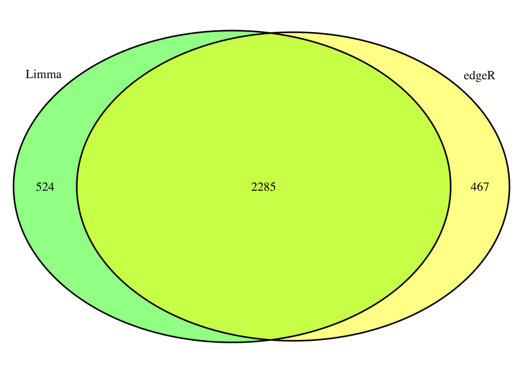

```
## (polygon[GRID.polygon.11], polygon[GRID.polygon.12], polygon[GRID.polygon.13], polygon[GRID.polygon.14], text[GRID.text.15], text[GRID.text.16], text[GRID.text.17], text[GRID.text.18], text[GRID.text.19])
```

```r
# Gets the toptags from the Population test that have a cut-off of 0,05 and stores this in a variable.
top_tags_pop_0.05<-topTags(lrtPop, n=16877, p.value = 0.05)

# combines sig. genes, of the Population test, at FDR=.05 between edgeR and limma approaches.
pop_inter<-intersect(rownames(fit.lv.Pop_FDR_0.05), rownames(top_tags_pop_0.05))

# creates a Venn Diagram to show the overlap of sig. genes (FDR=.05), of the Population test, between edgeR and limma approaches
draw.pairwise.venn(length(rownames(fit.lv.Pop_FDR_0.05)), length(rownames(top_tags_pop_0.05)), length(pop_inter),  category=c("Limma", "edgeR"), fill =c("green", "yellow"))
```

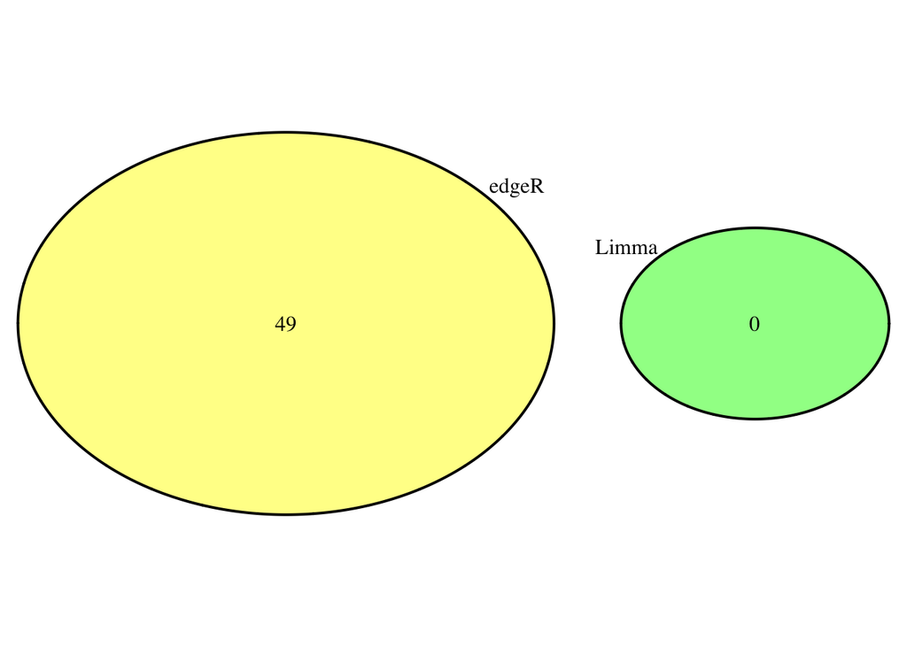

```
## (polygon[GRID.polygon.20], polygon[GRID.polygon.21], polygon[GRID.polygon.22], polygon[GRID.polygon.23], text[GRID.text.24], text[GRID.text.25], text[GRID.text.26], text[GRID.text.27])
```

```r
# Gets the toptags from the Treatment test that have a cut-off of 0,05 and strores this in a variable.
top_tags_lrt_0.05<-topTags(lrtTrt, n=16877, p.value = 0.05)

# combines sig. genes, of the Treatment test, at FDR=.05 between edgeR and limma approaches.
Trt_inter<-intersect(rownames(fit.lv.Trt_FDR_0.05), rownames(top_tags_lrt_0.05))

# creates a Venn Diagram to show the overlap of sig. genes (FDR=.05), of the Treatment test, between edgeR and limma approaches
draw.pairwise.venn(length(rownames(fit.lv.Trt_FDR_0.05)), length(rownames(top_tags_lrt_0.05)), length(Trt_inter), category=c("Limma", "edgeR"), fill =c("green", "yellow"))
```

Briefly comment on any differences in the numbers of differentially expressed genes between the edgeR and limma-voom approaches. In general do the approaches agree? Is one substanitally more conservative than the other?